# How life expectancy change over time for each continent?

```r
library(tidyverse)
library(modelr)
library(gapminder)
library(broom)
```

```r
gapminder
```

```
## # A tibble: 1,704 × 6
##    country     continent  year lifeExp      pop gdpPercap
##    <fct>       <fct>     <int>   <dbl>    <int>     <dbl>
##  1 Afghanistan Asia       1952    28.8  8425333      779.
##  2 Afghanistan Asia       1957    30.3  9240934      821.
##  3 Afghanistan Asia       1962    32.0 10267083      853.
##  4 Afghanistan Asia       1967    34.0 11537966      836.
##  5 Afghanistan Asia       1972    36.1 13079460      740.
##  6 Afghanistan Asia       1977    38.4 14880372      786.
##  7 Afghanistan Asia       1982    39.9 12881816      978.
##  8 Afghanistan Asia       1987    40.8 13867957      852.
##  9 Afghanistan Asia       1992    41.7 16317921      649.
## 10 Afghanistan Asia       1997    41.8 22227415      635.
## # ℹ 1,694 more rows
```

Life expectancy for a country is the mean length of life over people of a country. Using variables life expectancy and population of a country:

#1. derive a formula to compute life expectancy of a continent (a group of countries)

Un continente ha $k$ paesi, $i = 1,\dots,k$. Il paese $i$ ha $N_i$ abitanti (pop) e la persona $j$ ha durata di vita $L_{ij}$. L’aspettativa di vita del paese $i$, $e_i$ (lifeExp), è la media della durata di vita sugli abitanti:

$$e_i = \frac{1}{N_i}\sum_{j=1}^{N_i}
L_{ij} \quad\Longrightarrow\quad \sum_{j=1}^{N_i} L_{ij} = N_i\,
e_i$$

Il continente è un gruppo più grande di persone, quindi la sua aspettativa di vita è la media di $L_{ij}$ su tutti i suoi abitanti:

$$E = \frac{\sum_{i=1}^{k}\sum_{j=1}^{N_i}
L_{ij}}{\sum_{i=1}^{k} N_i}$$

Sostituendo $\sum_j L_{ij} = N_i e_i$ al numeratore si ottiene:

$$\boxed{E = \frac{\sum_{i=1}^{k} N_i\,
e_i}{\sum_{i=1}^{k} N_i} = \sum_{i=1}^{k} w_i\, e_i, \qquad w_i =
\frac{N_i}{\sum_m N_m}}$$

È la media ponderata per la popolazione delle aspettative di vita dei paesi, cioè weighted.mean(lifeExp, w = pop) in R. Non è la media semplice $\frac{1}{k}\sum_i e_i$, che darebbe all’Islanda lo stesso peso della Cina. Le due coincidono solo se tutti i paesi hanno la stessa popolazione.

#2. plot how life expectancy changed over time for each continent

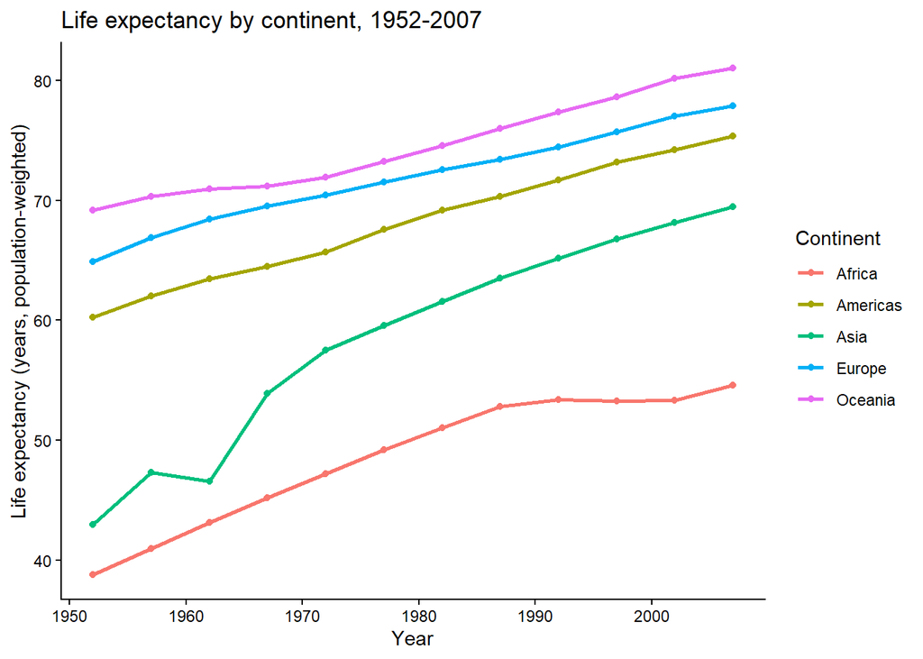

```r
continent_life <- gapminder %>%
  group_by(continent, year) %>%
  summarise(lifeExp = weighted.mean(lifeExp, w = pop), .groups = "drop")

# All continents in one plot
ggplot(continent_life, aes(year, lifeExp, colour = continent)) +
  geom_line(linewidth = 1) +
  geom_point() +
  labs(
    x = "Year",
    y = "Life expectancy (years, population-weighted)",
    colour = "Continent",
    title = "Life expectancy by continent, 1952-2007"
  ) +
  theme_classic()
```

#3. do the same for the whole planet

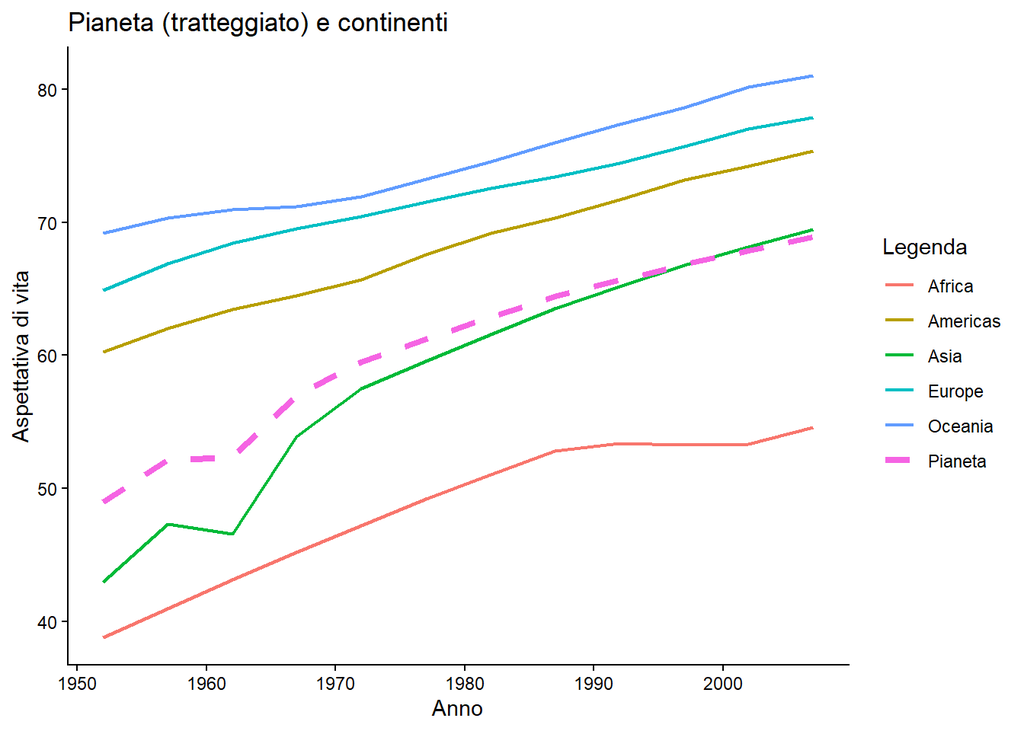

```r
world_life <- gapminder %>%
  group_by(year) %>%
  summarise(lifeExp = weighted.mean(lifeExp, pop), .groups = "drop") %>%
  mutate(continent = "Pianeta")

ggplot() +
  geom_line(data = continent_life,
            aes(year, lifeExp, colour = continent), linewidth = 0.8) +
  geom_line(data = world_life,
            aes(year, lifeExp, colour = continent),
            linewidth = 1.5, linetype = "dashed") +
  labs(x = "Anno", y = "Aspettativa di vita", colour = "Legenda",
       title = "Pianeta (tratteggiato) e continenti") +
  theme_classic()
```